# 고령화연구패널조사(KLoSA) 데이터분석

## **목 차**

> 1. 개요
> 2. 경제활동
>    - 연령대별 경제활동
>    - 성별별 경제활동
>    - 현 일자리의 고용형태
> 3. 소득
>    - 연령대별 근로소득
>    - 성별별 근로소득
> 4. 경제적지원
>    - 자녀에게 받은 금전적 지원
>    - 자녀에게 준 금전적 지원
> 5. 소비
>    - 주요 생활비
> 6. 건강상태
>    - ADL(Activities of Daily Living) - 일상생활 수행 능력
>    - IADL(Instrumental Activities of Daily Living) - 도구적 일상 활동수행 능력
>    - 음주 / 흡연과 만성질환
>    - 만성질환
>    - 인지기능
>    - 삶의 만족도

# 1. 개요

- 고령화연구패널조사는 향후 초고령사회로 변화해 가는 과정에서 효과적인 사회경제정책을 수립과 시행에 활용될 기초자료 생산
- 고령사회의 다양한 측면들을 여러 분야의 학제적 연구가 가능한 자료를 구축 및 선진국과 국제비교가 가능한 자료를 생산하고  
  정책개발과 학술연구의 기초자료로 활용
- 패널조사는 2006년 당시 제주도를 제외한 지역에 거주하는 45세 이상 중고령자 중 일반 가구 거주지를 대상으로 표집 및 조사실시
- 2006년부터 짝수 연도에는 동일한 조사 항목을 중심으로 기본조사를 실시하고, 2007년부터 홀수 연도에는 기본조사에 포함되지  
  않은 내용을 중심으로 특정 주제를 정하여 조사를 실시
- 조사 대상  
  고령화연구패널조사의 대상자는 대한민국 제주도를 제외한 지역에 거주하는 45세(1962년 이전생) 이상의 중고령자 개인을 대상으로  
  표본수 약 10,000명을 목표로 표집하여 10,254명이 패널로 구축하고 2014년에는 1962~1963년생을 중심으로 한 920명을 추가

## 1.1 데이터

### Loading

```r
library(tidyverse)
library(sqldf)
library(gridExtra)
library(fs)
dir_info("../input")
```

| path | type | size | permissions | modification_time | user | group | device_id | hard_links | special_device_id | inode | block_size | blocks | flags | generation | access_time | change_time | birth_time |
| --- | --- | --- | --- | --- | --- | --- | --- | --- | --- | --- | --- | --- | --- | --- | --- | --- | --- |
| ../input/klosa.csv | file | 12.73M | rw-r--r-- | 2019-04-24 06:38:36 | root | root | 39 | 1 | 0 | 734602267 | 1048576 | 26072 | 0 | 0 | 2019-05-01 02:35:30 | 2019-04-24 06:38:36 | 2019-04-24 06:38:36 |
| ../input/klosa.rda | file | 2.12M | rw-r--r-- | 2019-04-24 06:38:36 | root | root | 39 | 1 | 0 | 734602268 | 1048576 | 4352 | 0 | 0 | 2019-04-24 06:38:36 | 2019-04-24 06:38:36 | 2019-04-24 06:38:36 |

```r
read.csv("../input/klosa.csv") -> klosa
```

## 1.2 패널

### 1)패널 참여인원

```r
klosa %>% count(year)
```

| year | n |
| --- | --- |
| 2006 | 10254 |
| 2008 | 8688 |
| 2010 | 7920 |
| 2012 | 7486 |
| 2014 | 7029 |
| 2016 | 6618 |

### 2)패널의 연도별 연령대 비율

```r
klosa %>% filter(!is.na(year)&!is.na(ageg)) %>%
  select(year,ageg) %>%
  group_by(year,ageg) %>%
  summarise(n=n()) %>%
  mutate(total=sum(n)) %>%
  mutate(pct=round(n/total*100,1))->ageg_by_year
```

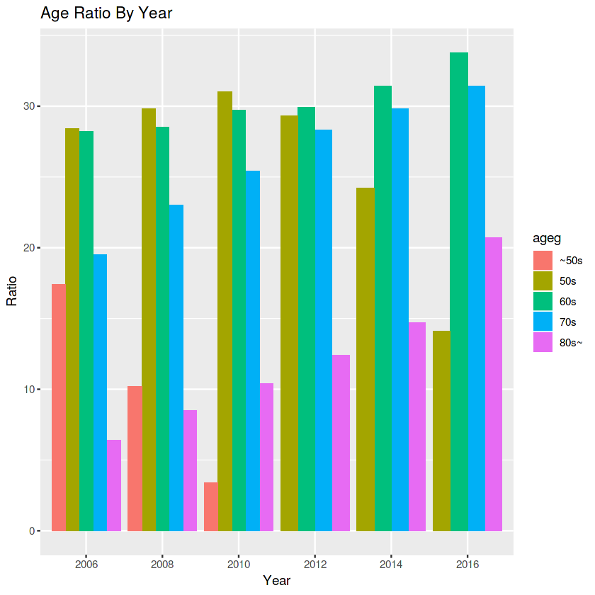

```r
ggplot(ageg_by_year,aes(factor(year) ,pct,fill=ageg))+
  geom_col(position="dodge")+
  ggtitle("Age Ratio By Year")+
  labs(x="Year", y="Ratio")
```

### 3)패널의 연도별 성별 인원

```r
klosa %>% filter(!is.na(year)&!is.na(gender)) %>%
  select(year,gender) %>%
  mutate(year=factor(year)) %>%
  group_by(year,gender) %>%
  summarise(n=n()) %>%
  mutate(total=sum(n)) %>%
  arrange(year)-> gender_by_year
```

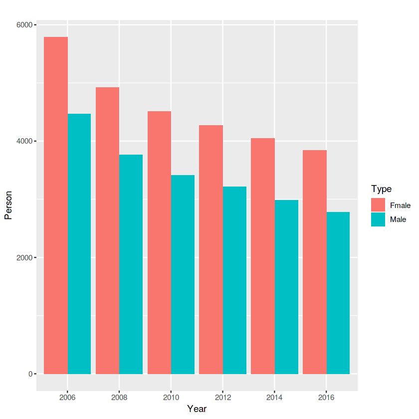

```r
gender_by_year %>% ggplot(aes(year, n, fill=gender))+
  #geom_line()
  geom_col(position='dodge')+
  labs(y="Person",x="Year",title="") +
  theme_grey() +
  scale_fill_discrete(name="Type",
                      labels=c("Fmale","Male"))
```

### 4)패널의 연도별 세대구성 ( 1세대:1G, 2세대:2G, 3세대:3G, 4세대:4G, 기타:Etc)

```r
klosa %>% filter(!is.na(family)) %>%
  select(year,family) %>%
  group_by(year,family) %>%
  summarise(n=n()) %>%
  mutate(total=sum(n))%>%
  mutate(pct=round(n/total*100,1)) -> family_by_year
```

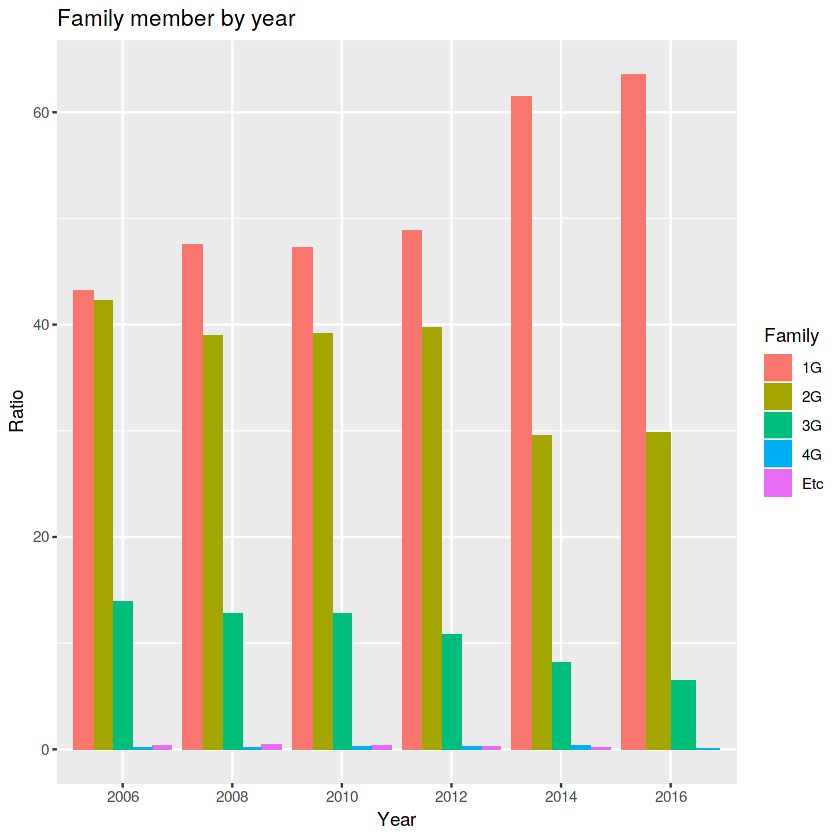

```r
ggplot(family_by_year,aes(factor(year) ,pct,fill=factor(family)))+
  geom_col(position="dodge")+
  ggtitle("Family member by year")+
  labs(x="Year", y="Ratio") +
  theme_grey() +
  scale_fill_discrete(name="Family",
                      labels=c("1G","2G","3G","4G","Etc"))
```

### 5)패널의 지역구성

```r
klosa %>% filter(!is.na(year)&!is.na(regiong)) %>%
  select(year,region,regiong) %>%
  group_by(year,regiong) %>%
  summarise(n=n()) %>%
  mutate(total=sum(n)) %>%
  mutate(pct=round(n/total*100,1)) ->region_by_year
```

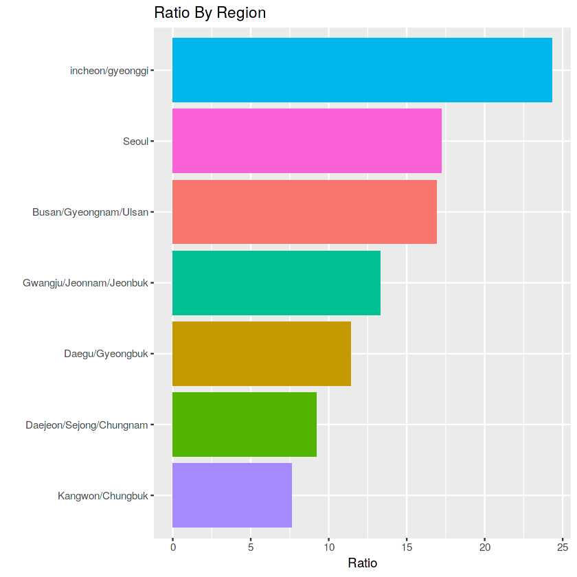

```r
ggplot(region_by_year[region_by_year$year == "2006",],aes(reorder(regiong,n),pct,fill=regiong))+
  geom_col(position="dodge")+
  coord_flip()+
  ggtitle("Ratio By Region")+
  labs(x="", y="Ratio")+
  guides(fill="none")
```

# 2. 경제활동

- Employment: 취업
- Jobless: 실업
- Inactive: 비경제제활동

## 2.1 연도별 연령대별 경제활동

```r
klosa %>%filter(!is.na(present_ecotype)) %>%
  select(year,ageg,present_ecotype) %>%
  mutate(year=factor(year)) %>%
  mutate(present_ecotype=ifelse(present_ecotype==1, "Employment",
                                ifelse(present_ecotype==2,"Jobless","Inactive"))) %>%
  count(year,ageg,present_ecotype) %>%
  group_by(year,ageg,present_ecotype) ->ecoact_ageg_year
```

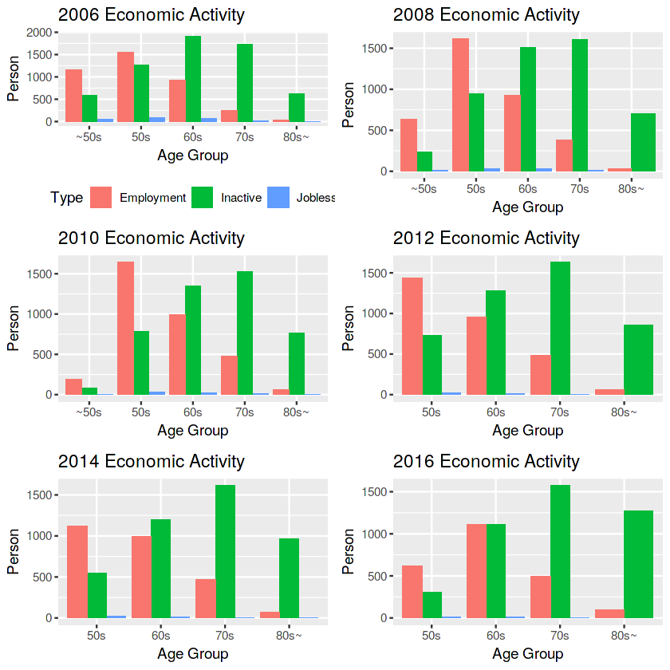

```r
eap1<- ggplot(ecoact_ageg_year[ecoact_ageg_year$year == "2006",], aes(ageg, n, fill=present_ecotype)) +
       geom_col(position='dodge')+
       labs(y="Person",x="Age Group",title="2006 Economic Activity") +
       theme_grey()+
       theme(legend.position = "bottom")+
       scale_fill_discrete(name = "Type")

eap2<- ggplot(ecoact_ageg_year[ecoact_ageg_year$year == "2008",], aes(ageg, n, fill=present_ecotype)) +
       geom_col(position='dodge')+
       labs(y="Person",x="Age Group",title="2008 Economic Activity") +
       theme_grey()+
       guides(fill="none")


eap3<- ggplot(ecoact_ageg_year[ecoact_ageg_year$year == "2010",], aes(ageg, n, fill=present_ecotype)) +
       geom_col(position='dodge')+
       labs(y="Person",x="Age Group",title="2010 Economic Activity") +
       theme_grey() +
       guides(fill="none")

eap4<-ggplot(ecoact_ageg_year[ecoact_ageg_year$year == "2012",], aes(ageg, n, fill=present_ecotype)) +
      geom_col(position='dodge')+
      labs(y="Person",x="Age Group",title="2012 Economic Activity") +
      theme_grey() +
      guides(fill="none")


eap5<- ggplot(ecoact_ageg_year[ecoact_ageg_year$year == "2014",], aes(ageg, n, fill=present_ecotype)) +
       geom_col(position='dodge')+
       labs(y="Person",x="Age Group",title="2014 Economic Activity") +
       theme_grey() +
       guides(fill="none")

eap6<- ggplot(ecoact_ageg_year[ecoact_ageg_year$year == "2016",], aes(ageg, n, fill=present_ecotype)) +
       geom_col(position='dodge')+
       labs(y="Person",x="Age Group",title="2016 Economic Activity") +
       theme_grey()  +
       guides(fill="none")
grid.arrange(eap1, eap2, eap3, eap4, eap5, eap6, ncol=2, nrow = 3)
```

## 2.2 연도별 경제활동상태

```r
klosa %>% filter(!is.na(present_ecotype)) %>%
    mutate(year=factor(year)) %>%
    select(year,present_ecotype) %>%
    count(year,present_ecotype) %>%
    group_by(year) %>%
    mutate(total=sum(n)) %>%
    mutate(pct=round(n/total*100,1))->ecoact_year
```

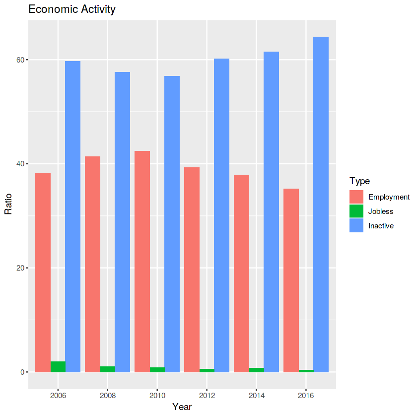

```r
ggplot(ecoact_year,aes(year, pct,fill=as.factor(present_ecotype))) +
  geom_col(position='dodge')+
  labs(y="Ratio",x="Year",title="Economic Activity") +
  theme_grey() +
  scale_fill_discrete(name="Type",
                      labels=c("Employment","Jobless","Inactive"))
```

## 2.3 연도별 성별 경제활동

```r
klosa %>% filter(!is.na(gender)&!is.na(present_ecotype)) %>%
  mutate(year=factor(year)) %>%
  select(year,gender,present_ecotype) %>%
  group_by(year,gender,present_ecotype) %>%
  summarise(n=n()) %>%
  mutate(total=sum(n)) %>%
  mutate(pct=round(n/total*100,1)) ->ecoact_gender_year
```

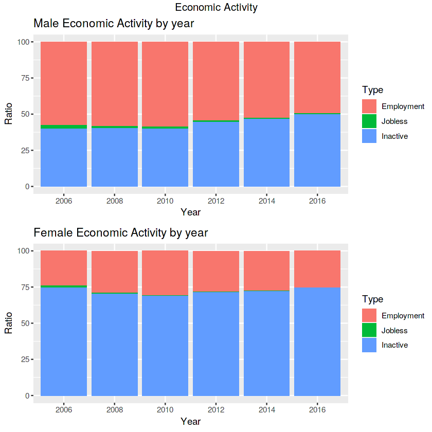

```r
eag1<-ggplot(ecoact_gender_year[ecoact_gender_year$gender=="male",],aes(year, pct ,fill=as.factor(present_ecotype))) +
  geom_col()+
  labs(y="Ratio",x="Year",title="Male Economic Activity by year") +
  theme_grey() +
  scale_fill_discrete(name="Type",
                      labels=c("Employment","Jobless","Inactive"))

eag2<-ggplot(ecoact_gender_year[ecoact_gender_year$gender=="female",],aes(year, pct ,fill=as.factor(present_ecotype))) +
  geom_col()+
  labs(y="Ratio",x="Year",title="Female Economic Activity by year") +
  theme_grey() +
  scale_fill_discrete(name="Type",
                      labels=c("Employment","Jobless","Inactive"))

grid.arrange(eag1, eag2, nrow = 2 , top ="Economic Activity")
```

## 2006년 45세~55세, 56세 ~ 65세, 66세~75세, 76세~85세, 86세~95세의 연령그룹 데이터

```r
klosa %>% filter((year==2006 & age < 56) |
                     (year==2008 & age < 58) |
                     (year==2010 & age < 60) |
                     (year==2012 & age < 62) |
                     (year==2014 & age < 64) |
                     (year==2016 & age < 66)) %>%
    select(year,gender,age,ageg,emp,present_ecotype,earned,adl,iadl) %>% mutate(tfr="45to55") -> r1


klosa %>% filter((year==2006 & age > 55 & age < 66) |
                     (year==2008 & age > 57 & age < 68) |
                     (year==2010 & age > 59 & age < 70) |
                     (year==2012 & age > 61 & age < 72) |
                     (year==2014 & age > 63 & age < 74) |
                     (year==2016 & age > 65 & age < 76)) %>%
    select(year,gender,age,ageg,emp,present_ecotype,earned,adl,iadl) %>% mutate(tfr="56to65") -> r2


klosa %>% filter((year==2006 & age > 65 & age < 76) |
                     (year==2008 & age > 67 & age < 78) |
                     (year==2010 & age > 69 & age < 80) |
                     (year==2012 & age > 71 & age < 82) |
                     (year==2014 & age > 73 & age < 84) |
                     (year==2016 & age > 75 & age < 86)) %>%
    select(year,gender,age,ageg,emp,present_ecotype,earned,adl,iadl) %>% mutate(tfr="66to75") -> r3


klosa %>% filter((year==2006 & age > 75 & age < 86) |
                     (year==2008 & age > 77 & age < 88) |
                     (year==2010 & age > 79 & age < 90) |
                     (year==2012 & age > 81 & age < 92) |
                     (year==2014 & age > 83 & age < 94) |
                     (year==2016 & age > 85 & age < 96)) %>%
    select(year,gender,age,ageg,emp,present_ecotype,earned,adl,iadl) %>% mutate(tfr="76to85") -> r4


klosa %>% filter((year==2006 & age > 85 & age < 96) |
                     (year==2008 & age > 87 & age < 98) |
                     (year==2010 & age > 89 & age < 100) |
                     (year==2012 & age > 91 & age < 102) |
                     (year==2014 & age > 93 & age < 104) |
                     (year==2016 & age > 95 & age < 106)) %>%
    select(year,gender,age,ageg,emp,present_ecotype,earned,adl,iadl) %>% mutate(tfr="86to95") -> r5

rbind(r1,r2,r3,r4,r5) -> klosabyage
```

## 2.4 2006년 ~ 2016년 연령대별 경제활동

```r
klosabyage %>% mutate(present_ecotype=ifelse(present_ecotype==1, "Employment",
                                             ifelse(present_ecotype==2,"Jobless","Inactive"))) %>%
              group_by(age,tfr,present_ecotype) %>%
              summarise(n=n()) %>%
              mutate(total=sum(n)) %>%
              mutate(pct=round(n/total*100,1))->ecoact_ageg_year
```

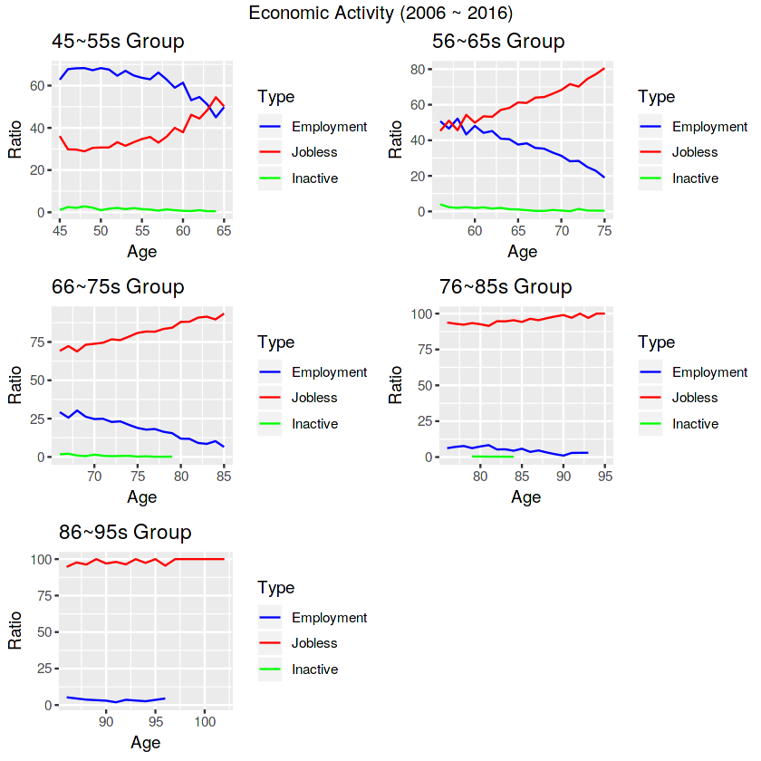

```r
ggplot(ecoact_ageg_year[ecoact_ageg_year$tfr=="45to55",],aes(age,pct,color=present_ecotype))+
      geom_line() +
      labs(y="Ratio",x="Age",title="45~55s Group") +
      scale_color_manual( values=c("Blue","Red","Green"),
                          name = ("Type"),
                          labels = c("Employment","Jobless","Inactive"))-> p1
 ggplot(ecoact_ageg_year[ecoact_ageg_year$tfr=="56to65",],aes(age,pct,color=present_ecotype))+
      geom_line()+
      labs(y="Ratio",x="Age",title="56~65s Group") +
      scale_color_manual( values=c("Blue","Red","Green"),
                       name = ("Type"),
                       labels = c("Employment","Jobless","Inactive")) -> p2
 ggplot(ecoact_ageg_year[ecoact_ageg_year$tfr=="66to75",],aes(age,pct,color=present_ecotype))+
   geom_line()+
   labs(y="Ratio",x="Age",title="66~75s Group") +
   scale_color_manual( values=c("Blue","Red","Green"),
                       name = ("Type"),
                       labels = c("Employment","Jobless","Inactive")) -> p3
 ggplot(ecoact_ageg_year[ecoact_ageg_year$tfr=="76to85",],aes(age,pct,color=present_ecotype))+
   geom_line()+
   labs(y="Ratio",x="Age",title="76~85s Group") +
   scale_color_manual( values=c("Blue","Red","Green"),
                       name = ("Type"),
                       labels = c("Employment","Jobless","Inactive")) -> p4
 ggplot(ecoact_ageg_year[ecoact_ageg_year$tfr=="86to95",],aes(age,pct,color=present_ecotype))+
   geom_line()+
   labs(y="Ratio",x="Age",title="86~95s Group") +
   scale_color_manual( values=c("Blue","Red","Green"),
                       name = ("Type"),
                       labels = c("Employment","Jobless","Inactive")) -> p5
 grid.arrange(p1, p2, p3, p4, p5, top="Economic Activity (2006 ~ 2016)", nrow = 3)
```

## 2.5 2006년 ~ 2016년 연령대별 성별 경제활동

```r
klosabyage %>% mutate(present_ecotype=ifelse(present_ecotype==1, "Employment",
                                              ifelse(present_ecotype==2,"Jobless","Inactive"))) %>%
   select(age,gender,tfr,present_ecotype) %>%
   group_by(age,gender,tfr,present_ecotype) %>%
   summarise(n=n()) %>%
   mutate(total=sum(n)) %>%
   mutate(pct=round(n/total*100,1)) ->ecoact_gender
```

### 45세~55세 , 56세~65세 그룹의 활동

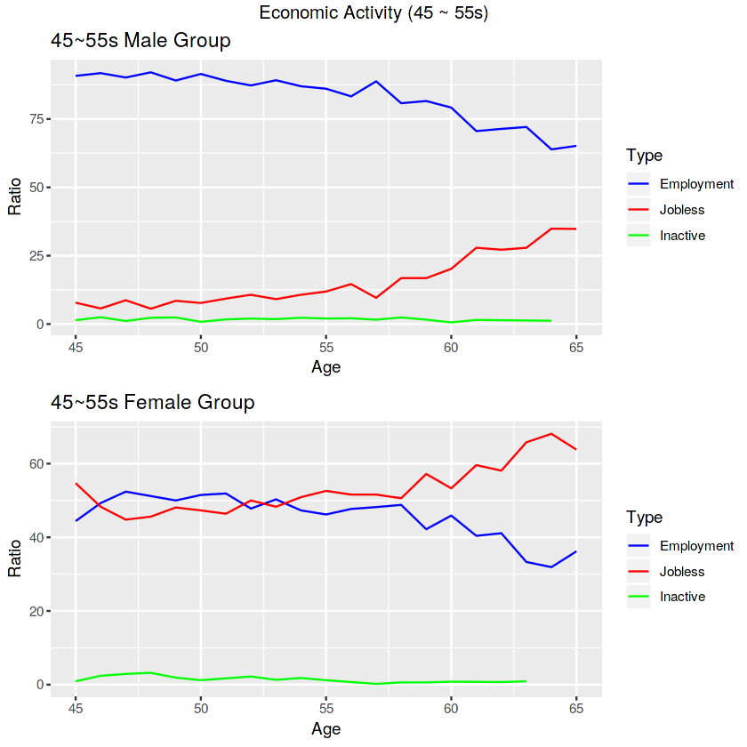

```r
ggplot(ecoact_gender[ecoact_gender$tfr=="45to55" & ecoact_gender$gender=="male",],aes(age,pct,color=present_ecotype))+
   geom_line()+
   labs(y="Ratio",x="Age",title="45~55s Male Group") +
   scale_color_manual( values=c("Blue","Red","Green"),
                       name = ("Type"),
                       labels = c("Employment","Jobless","Inactive")) -> g1

 ggplot(ecoact_gender[ecoact_gender$tfr=="45to55" & ecoact_gender$gender=="female",],aes(age,pct,color=present_ecotype))+
   geom_line()+
   labs(y="Ratio",x="Age",title="45~55s Female Group") +
   scale_color_manual( values=c("Blue","Red","Green"),
                       name = ("Type"),
                       labels = c("Employment","Jobless","Inactive")) -> g2
grid.arrange(g1, g2, top="Economic Activity (45 ~ 55s)", nrow = 2)
```

```r
ggplot(ecoact_gender[ecoact_gender$tfr=="56to65" & ecoact_gender$gender=="male",],aes(age,pct,color=present_ecotype))+
   geom_line()+
   labs(y="Ratio",x="Age",title="56~65s Male Group") +
   scale_color_manual( values=c("Blue","Red","Green"),
                       name = ("Type"),
                       labels = c("Employment","Jobless","Inactive")) -> g3
```

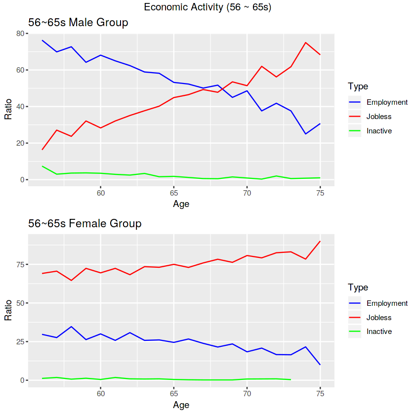

```r
ggplot(ecoact_gender[ecoact_gender$tfr=="56to65" & ecoact_gender$gender=="female",],aes(age,pct,color=present_ecotype))+
   geom_line()+
   labs(y="Ratio",x="Age",title="56~65s Female Group") +
   scale_color_manual( values=c("Blue","Red","Green"),
                       name = ("Type"),
                       labels = c("Employment","Jobless","Inactive")) -> g4
grid.arrange(g3, g4, top="Economic Activity (56 ~ 65s)", nrow = 2)
```

## 2.6 연도별 일자리 고용형태 [임금고용, 개인사업, 무급(가족,친척의 일을 돕는다)]

```r
klosa %>% filter(!is.na(emp)&!is.na(year)) %>%
  select(year,emp) %>%
  mutate(emps=ifelse(emp==3|emp==4,3,emp)) %>%
  group_by(year,emps) %>%
  summarise(n=n()) %>%
  mutate(total=sum(n)) %>%
  mutate(pct=round(n/total*100,1))->ecoact_emp_year
```

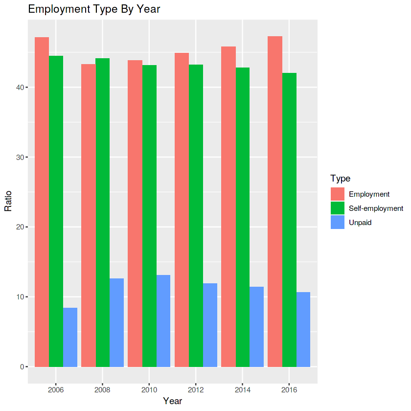

```r
ggplot(ecoact_emp_year,aes(as.factor(year), pct ,fill=as.factor(emps))) +
  geom_col(position='dodge')+
  labs(y="Ratio",x="Year",title="Employment Type By Year") +
  theme_grey() +
  scale_fill_discrete(name="Type",
                      labels=c("Employment","Self-employment","Unpaid"))
```

## 2.7 2006년 ~ 2016년 연령별 일자리 고용형태

```r
klosabyage %>% filter(!is.na(emp)&!is.na(year)) %>%
   select(age,tfr,emp) %>%
   mutate(emps=ifelse(emp==3|emp==4,3,emp)) %>%
   group_by(age,tfr,emps) %>%
   summarise(n=n()) %>%
   mutate(total=sum(n)) %>%
   mutate(pct=round(n/total*100,1))->ecoact_emp_tfr
```

### 45세~55세 , 56세~65세 그룹의 고용형태

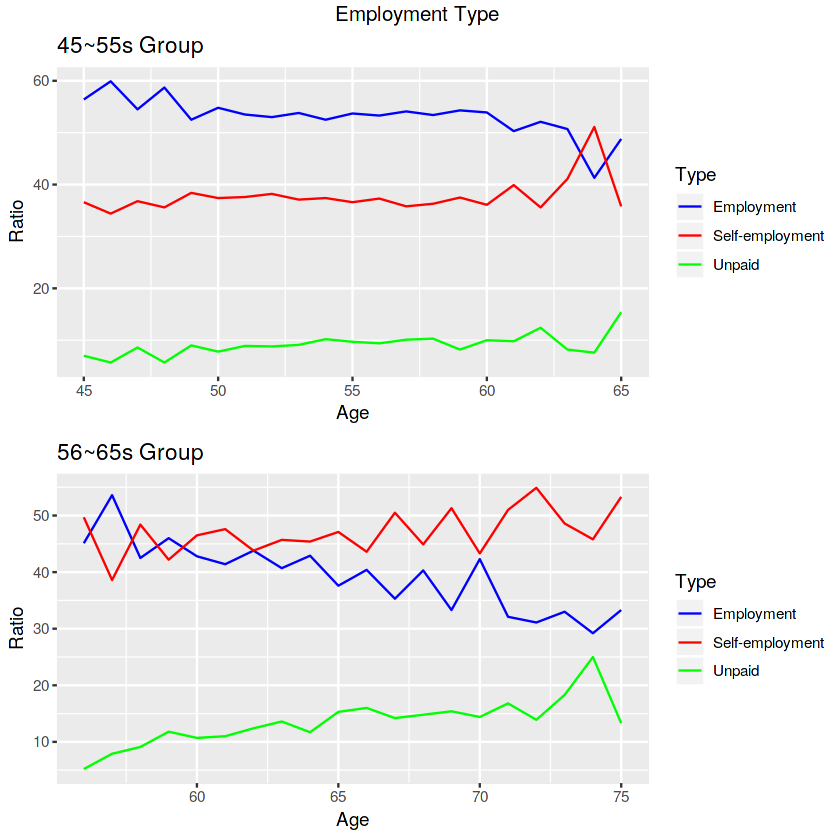

```r
ggplot(ecoact_emp_tfr[ecoact_emp_tfr$tfr=="45to55",],aes(age,pct,color=factor(emps)))+
   geom_line()+
   labs(y="Ratio",x="Age",title="45~55s Group") +
   scale_color_manual( values=c("Blue","Red","Green"),
                       name = ("Type"),
                       labels = c("Employment","Self-employment","Unpaid")) -> e1

 ggplot(ecoact_emp_tfr[ecoact_emp_tfr$tfr=="56to65",],aes(age,pct,color=factor(emps)))+
   geom_line()+
   labs(y="Ratio",x="Age",title="56~65s Group") +
   scale_color_manual( values=c("Blue","Red","Green"),
                       name = ("Type"),
                       labels = c("Employment","Self-employment","Unpaid")) -> e2

 grid.arrange(e1, e2, top="Employment Type ", nrow = 2)
```

## 3. 소득

### 3.1 연도별 근로소득

#### (2006년 45세~55세, 56세 ~ 65세, 66세~75세, 76세~85세, 86세~95세의 연령그룹)

```r
klosabyage %>% select(year,tfr,earned)%>%
               filter(!is.na(earned)) %>%
               mutate(tfr=ifelse(tfr=="45to55","45~55s",
                          ifelse(tfr=="56to65","56~65s",
                          ifelse(tfr=="66to75","66~75s",
                          ifelse(tfr=="76to85","76~85s", "86~95s"))))) %>%
               rename(agegroup=tfr) %>%
               group_by(year,agegroup) %>%
               summarise(mean = mean(earned, na.rm=T)) -> ep1
```

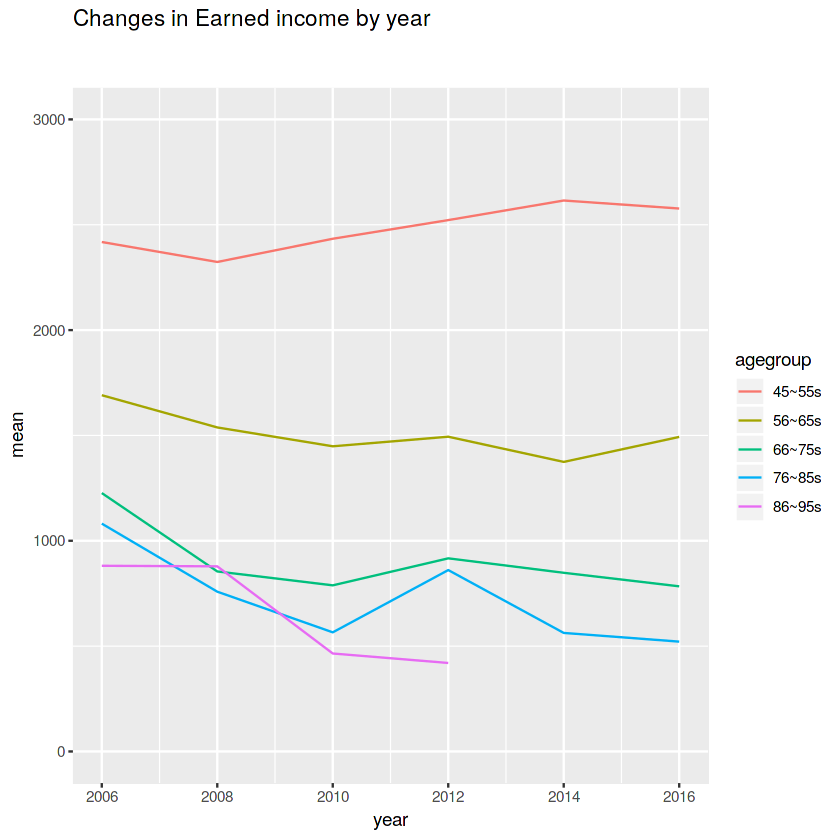

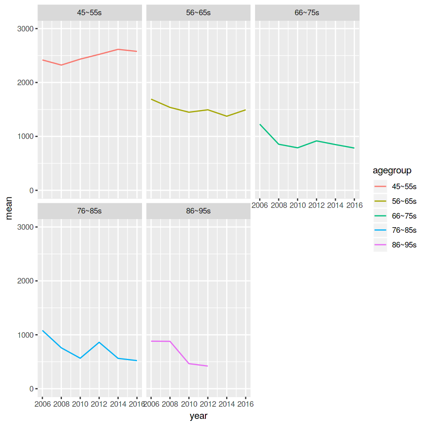

```r
ep1 %>% ggplot(aes(year,mean,color=agegroup))+geom_line()+ylim(0,3000)+ggtitle("Changes in Earned income by year\n\n")
ep1 %>% ggplot(aes(year,mean,color=agegroup))+geom_line()+facet_wrap(~ agegroup)+ylim(0,3000)
```

### 3.2 연도별 연령대의 소득

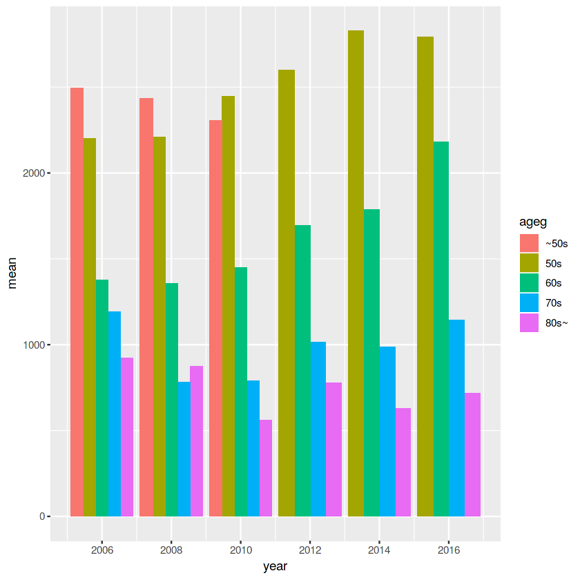

```r
klosa %>%
    filter(!is.na(earned)) %>%
    select(year,ageg,earned) %>%
    group_by(year,ageg) %>%
    summarise(mean=mean(earned)) %>%
    ggplot(aes(year,mean,fill=ageg))+geom_col(position="dodge") +
    scale_x_continuous(breaks=c(2006,2008,2010,2012,2014,2016))
```

### 3.3 연도에 따른 연령별 근로소득의 변화

```r
klosa %>%
filter(!is.na(earned)) %>%
filter(ageg=="~50s") %>%
select(year,ageg,earned) %>%
group_by(year) %>%
summarise("~50"=mean(earned)) ->f

klosa %>%
filter(!is.na(earned)) %>%
filter(ageg=="50s") %>%
select(year,ageg,earned) %>%
group_by(year) %>%
summarise("50s"=mean(earned)) ->g


klosa %>%
filter(!is.na(earned)) %>%
filter(ageg=="60s") %>%
select(year,ageg,earned) %>%
group_by(year) %>%
summarise("60s"=mean(earned)) ->h

klosa %>%
filter(!is.na(earned)) %>%
filter(ageg=="70s") %>%
select(year,ageg,earned) %>%
group_by(year) %>%
summarise("70s"=mean(earned)) ->i

klosa %>%
filter(!is.na(earned)) %>%
filter(ageg=="80s~") %>%
select(year,ageg,earned) %>%
group_by(year) %>%
summarise("80s~"=mean(earned)) ->j
```

```r
right_join(f,g) %>% left_join(h) %>% left_join(i) %>% left_join(j) ->fghij
fghij
```

| year | ~50 | 50s | 60s | 70s | 80s~ |
| --- | --- | --- | --- | --- | --- |
| 2006 | 2492.911 | 2203.051 | 1378.692 | 1191.8818 | 921.6316 |
| 2008 | 2435.997 | 2210.155 | 1356.993 | 782.8668 | 874.4355 |
| 2010 | 2306.345 | 2447.349 | 1448.460 | 788.4990 | 559.1562 |
| 2012 | NA | 2600.991 | 1695.823 | 1016.3766 | 777.0139 |
| 2014 | NA | 2829.167 | 1786.510 | 988.3170 | 628.2128 |
| 2016 | NA | 2793.422 | 2179.928 | 1144.0840 | 717.2806 |

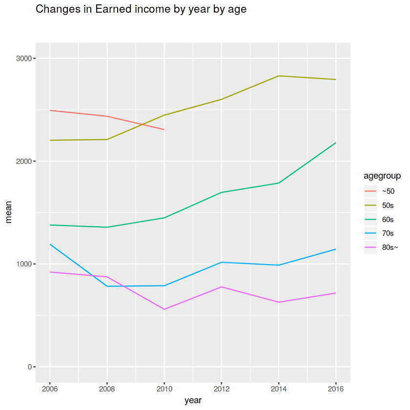

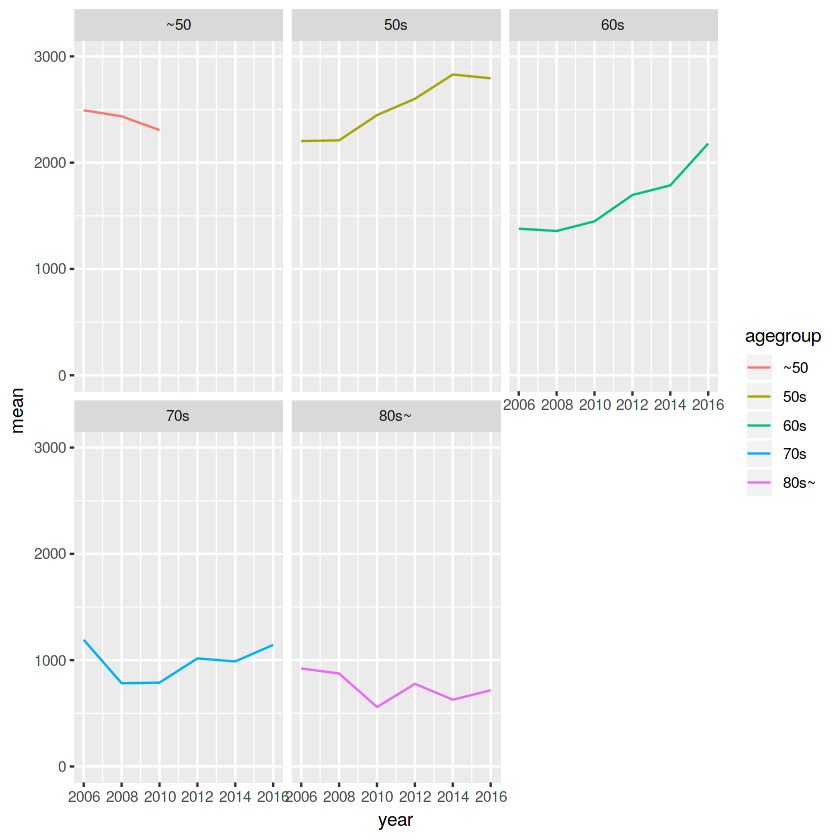

```r
gather(fghij, key="agegroup", value="mean",`~50`,`50s`,`60s`,`70s`,`80s~`) -> gathering2

gathering2 %>% ggplot(aes(year,mean,color=agegroup))+geom_line()+ylim(0,3000)+ggtitle("Changes in Earned income by year by age\n\n")
gathering2 %>% ggplot(aes(year,mean,color=agegroup))+geom_line()+facet_wrap(~ agegroup)+ylim(0,3000)
```

### 3.4 연도별 성별 근로소득

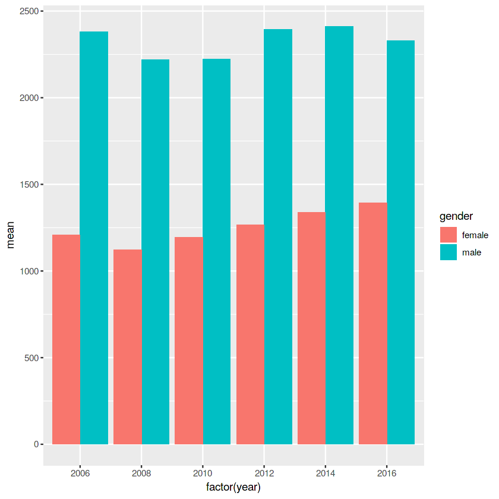

```r
klosa %>%
    filter(!is.na(earned)) %>%
    select(year,gender,earned) %>%
    group_by(year,gender) %>%
    summarise(mean=mean(earned)) -> meanbygender

meanbygender %>% ggplot(aes(factor(year),mean,fill=gender))+geom_col(position="dodge")
```

### 3.5 연도별 성별 소득의 차이(남성의 소득 - 여성의 소득)

```r
library(sqldf)
sqldf("select x.year, abs(x.mean-y.mean) as gap from
            (select year, mean from meanbygender where year==2006 and gender=='female') x,
            (select year, mean from meanbygender where year==2006 and gender=='male') y
      where x.year=y.year") -> gap2006

sqldf("select x.year, abs(x.mean-y.mean) as gap from
            (select year, mean from meanbygender where year==2008 and gender=='female') x,
            (select year, mean from meanbygender where year==2008 and gender=='male') y
      where x.year=y.year") -> gap2008

sqldf("select x.year, abs(x.mean-y.mean) as gap from
            (select year, mean from meanbygender where year==2010 and gender=='female') x,
            (select year, mean from meanbygender where year==2010 and gender=='male') y
      where x.year=y.year") -> gap2010

sqldf("select x.year, abs(x.mean-y.mean) as gap from
            (select year, mean from meanbygender where year==2012 and gender=='female') x,
            (select year, mean from meanbygender where year==2012 and gender=='male') y
      where x.year=y.year") -> gap2012

sqldf("select x.year, abs(x.mean-y.mean) as gap from
            (select year, mean from meanbygender where year==2014 and gender=='female') x,
            (select year, mean from meanbygender where year==2014 and gender=='male') y
      where x.year=y.year") -> gap2014

sqldf("select x.year, abs(x.mean-y.mean) as gap from
            (select year, mean from meanbygender where year==2016 and gender=='female') x,
            (select year, mean from meanbygender where year==2016 and gender=='male') y
      where x.year=y.year") -> gap2016
```

| year | gap |
| --- | --- |
| 2006 | 1173.0119 |
| 2008 | 1097.9697 |
| 2010 | 1026.8632 |
| 2012 | 1128.2876 |
| 2014 | 1072.6811 |
| 2016 | 937.0045 |

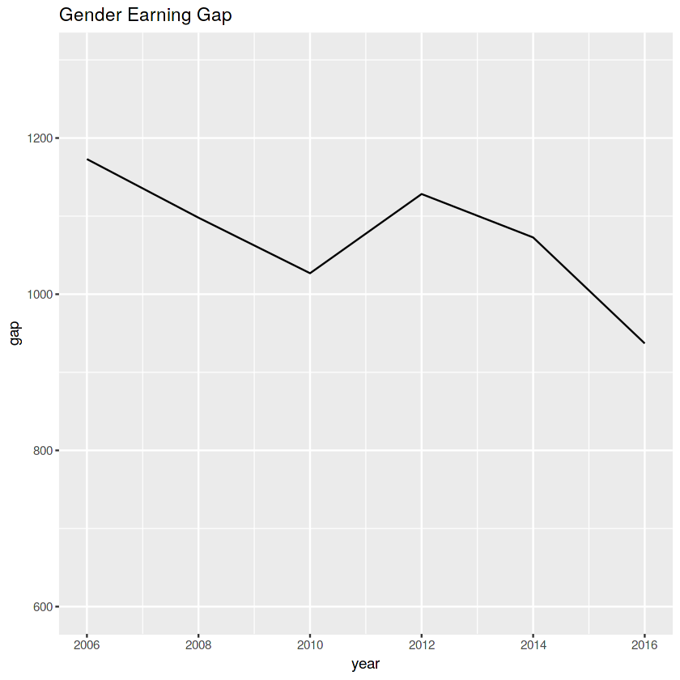

```r
(rbind(gap2006,gap2008,gap2010,gap2012,gap2014,gap2016) -> gendergap)
gendergap %>%
    ggplot(aes(year,gap))+geom_line()+
    scale_x_continuous(breaks=c(2006,2008,2010,2012,2014,2016))+
    ggtitle("Gender Earning Gap") +ylim(600,1300)
```

### 3.6 연도별 근로소득의 구성 (임금,자영업, 농어업, 부업 )

- 근로총소득=임금소득+자영업소득+농어업소득+부업소득
  - wage : 임금소득
  - selfemployed : 자영업(사업체운영) 소득
  - agriculture : 농어업 소득
  - sideline : 부업소득

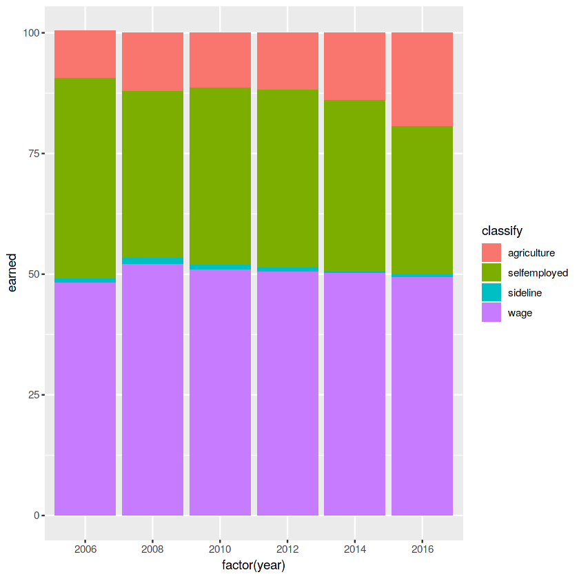

```r
klosa %>%
    select(year,earned,wage,selfemployed,agriculture,sideline) %>%
    group_by(year) %>%
    summarize(earned=sum(earned,na.rm=T),
              wage=sum(wage,na.rm=T),
              selfemployed=sum(selfemployed,na.rm=T),
              agriculture=sum(agriculture,na.rm=T),
              sideline=sum(sideline,na.rm=T)) %>%
    mutate(wage=wage/earned*100) %>%
    mutate(selfemployed=selfemployed/earned*100) %>%
    mutate(agriculture=agriculture/earned*100) %>%
    mutate(sideline=sideline/earned*100) -> www

www_long=gather(www, key="classify", value="earned",`wage`,`selfemployed`,`agriculture`,`sideline`)
www_long %>% ggplot(aes(factor(year),earned,fill=classify))+geom_col()
```

### 3.7 연도별 연령별 총소득 / 연도별 성별 총소득

- 개인총소득(근로총소득+자산총소득+공적이전총소득+사적이전총소득+개인연금소득+ 기타소득)

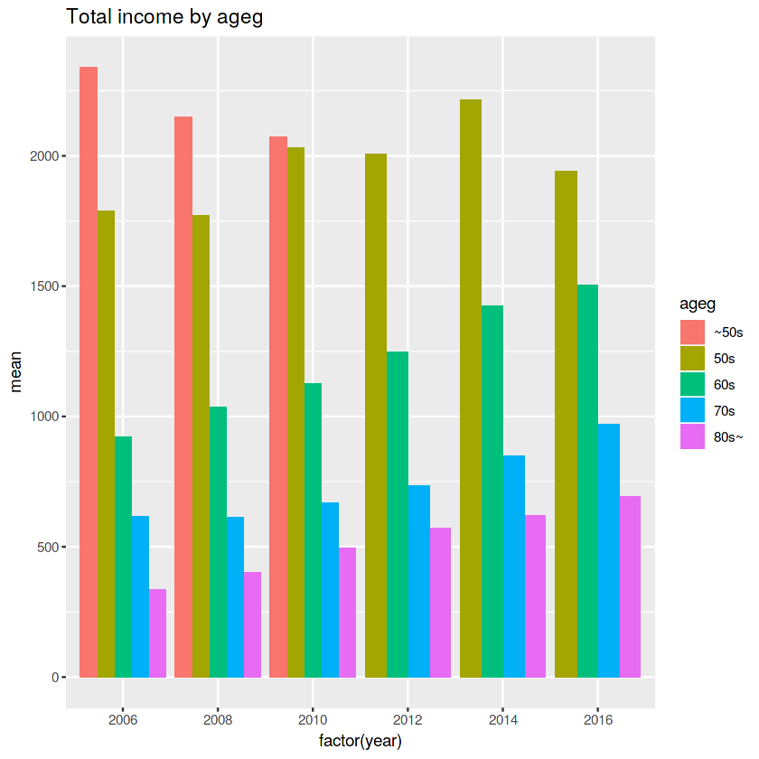

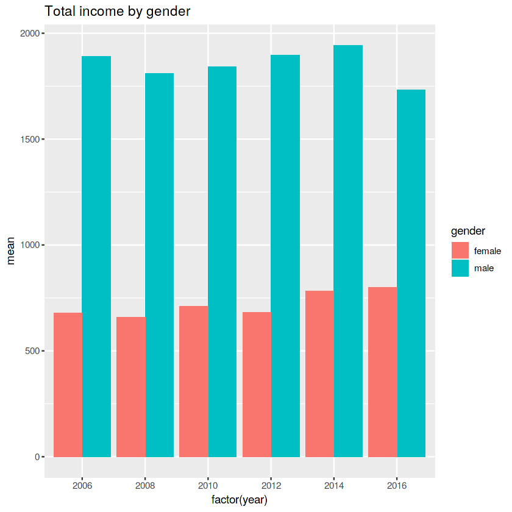

```r
(klosa %>%
    filter(!is.na(p_inc)) %>%
    select(year,ageg,p_inc) %>%
    group_by(year,ageg) %>%
    summarise(mean = mean(p_inc)) %>%
    ggplot(aes(factor(year),mean,fill=ageg))+geom_col(position="dodge") +
    ggtitle("Total income by ageg")-> p_incbyyear)

klosa %>%
    filter(!is.na(p_inc)) %>%
    select(year,gender,p_inc) %>%
    group_by(year,gender) %>%
    summarise(mean=mean(p_inc)) -> p_incbygender

p_incbygender %>%
    ggplot(aes(factor(year),mean,fill=gender))+geom_col(position="dodge") +
    ggtitle("Total income by gender")
```

### 3.8 성별 총소득의 차이(남자의 총소득 - 여자의 총소득)

| year | gap |
| --- | --- |
| 2006 | 1212.1318 |
| 2008 | 1151.7313 |
| 2010 | 1130.3365 |
| 2012 | 1213.0437 |
| 2014 | 1162.4548 |
| 2016 | 932.8697 |

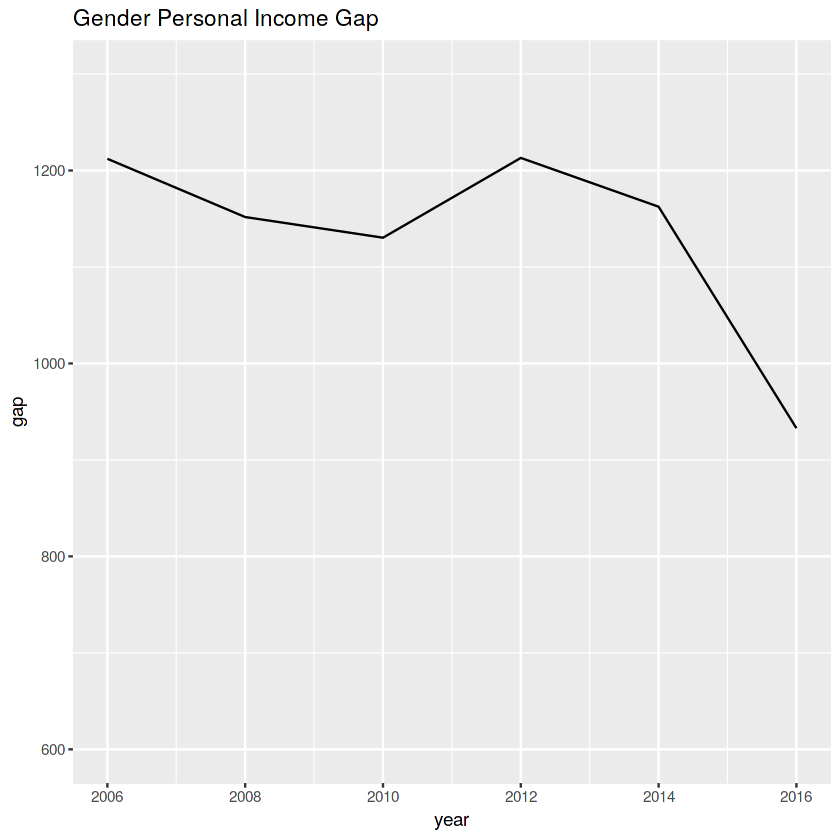

```r
library(sqldf)
sqldf("select x.year, abs(x.mean-y.mean) as gap from
            (select year, mean from p_incbygender where year==2006 and gender=='female') x,
            (select year, mean from p_incbygender where year==2006 and gender=='male') y
      where x.year=y.year") -> pgap2006

sqldf("select x.year, abs(x.mean-y.mean) as gap from
            (select year, mean from p_incbygender where year==2008 and gender=='female') x,
            (select year, mean from p_incbygender where year==2008 and gender=='male') y
      where x.year=y.year") -> pgap2008

sqldf("select x.year, abs(x.mean-y.mean) as gap from
            (select year, mean from p_incbygender where year==2010 and gender=='female') x,
            (select year, mean from p_incbygender where year==2010 and gender=='male') y
      where x.year=y.year") -> pgap2010

sqldf("select x.year, abs(x.mean-y.mean) as gap from
            (select year, mean from p_incbygender where year==2012 and gender=='female') x,
            (select year, mean from p_incbygender where year==2012 and gender=='male') y
      where x.year=y.year") -> pgap2012

sqldf("select x.year, abs(x.mean-y.mean) as gap from
            (select year, mean from p_incbygender where year==2014 and gender=='female') x,
            (select year, mean from p_incbygender where year==2014 and gender=='male') y
      where x.year=y.year") -> pgap2014

sqldf("select x.year, abs(x.mean-y.mean) as gap from
            (select year, mean from p_incbygender where year==2016 and gender=='female') x,
            (select year, mean from p_incbygender where year==2016 and gender=='male') y
      where x.year=y.year") -> pgap2016


(rbind(pgap2006,pgap2008,pgap2010,pgap2012,pgap2014,pgap2016) -> gendergap2)
gendergap2 %>%
    ggplot(aes(year,gap))+geom_line()+
    scale_x_continuous(breaks=c(2006,2008,2010,2012,2014,2016))+
    ggtitle("Gender Personal Income Gap") +ylim(600,1300)
```

## 4. 경제적지원

### 4.1 연도별 연령별 금전적 지원(자녀에게 지원 받은 금액)

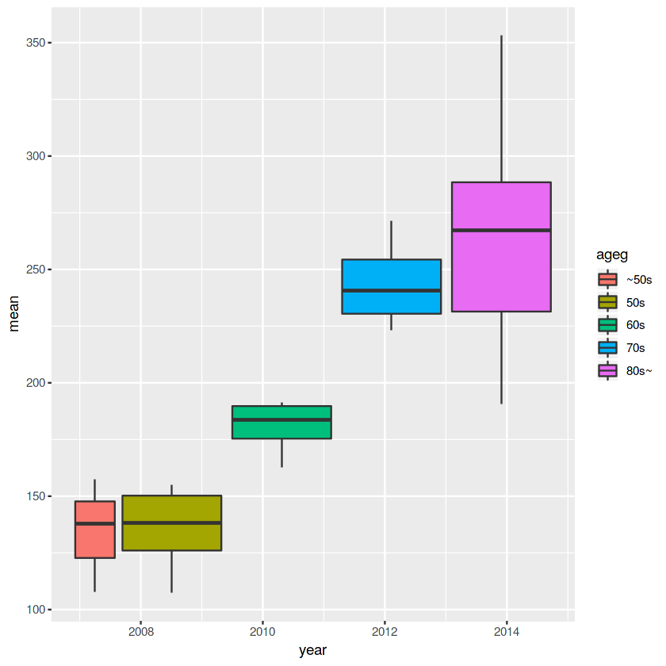

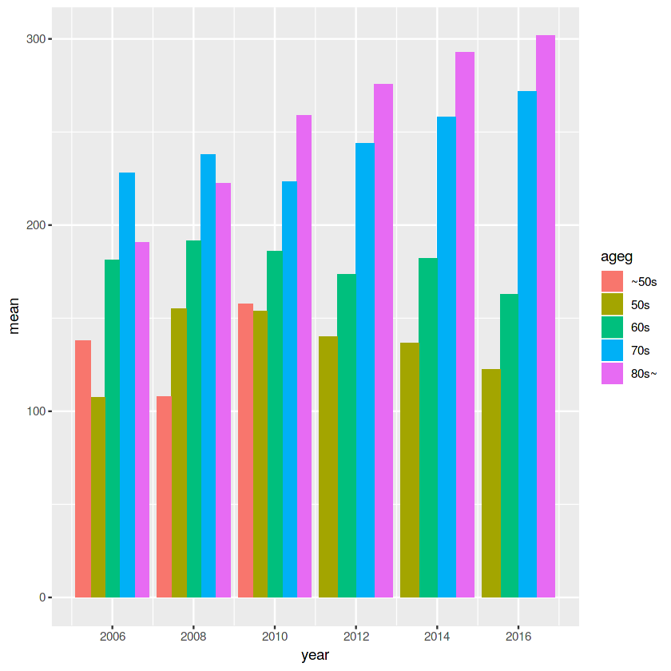

```r
klosa %>%
    filter(!is.na(m_fromchildren)) %>%
    select(year,ageg,m_fromchildren) %>%
    group_by(year,ageg) %>%
    summarise(mean = mean(m_fromchildren)) %>%
    ggplot(aes(year,mean,fill=ageg))+geom_boxplot() +
    scale_x_continuous(breaks=c(2006,2008,2010,2012,2014,2016))

# 이상치 제거 후 그래프그리기
klosa %>% filter(m_fromchildren<14000) -> klosa_from
klosa_from %>% filter(!is.na(m_fromchildren)) %>%
    select(year,ageg,m_fromchildren) %>%
    group_by(year,ageg) %>%
    summarise(mean = mean(m_fromchildren)) %>%
    ggplot(aes(year,mean,fill=ageg))+geom_col(position="dodge") +
    scale_x_continuous(breaks=c(2006,2008,2010,2012,2014,2016))
```

### 4.2 연도별 연령별 금전적 지원(자녀에게 지원한 금액)

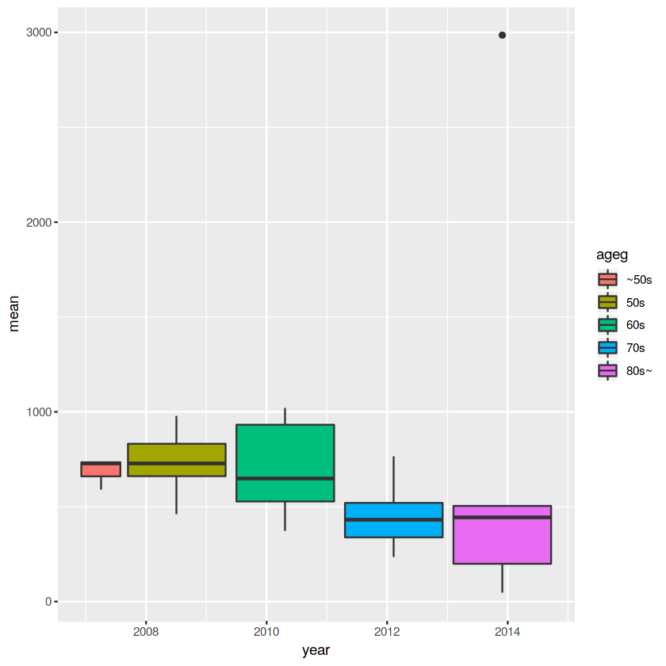

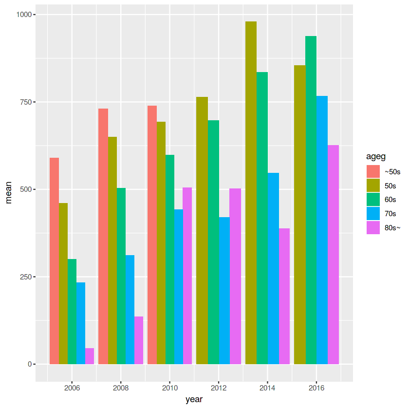

```r
klosa %>%
    filter(!is.na(m_tochildren)) %>%
    select(year,ageg,m_tochildren) %>%
    group_by(year,ageg) %>%
    summarise(mean = mean(m_tochildren)) %>%
    ggplot(aes(year,mean,fill=ageg))+geom_boxplot() +
    scale_x_continuous(breaks=c(2006,2008,2010,2012,2014,2016))

# 이상치 제거 후 그래프그리기
klosa %>% filter(m_tochildren<20000) -> klosa_to
klosa_to %>% filter(!is.na(m_tochildren)) %>%
    select(year,ageg,m_tochildren) %>%
    group_by(year,ageg) %>%
    summarise(mean = mean(m_tochildren)) %>%
    ggplot(aes(year,mean,fill=ageg))+geom_col(position="dodge") +
    scale_x_continuous(breaks=c(2006,2008,2010,2012,2014,2016))
```

### 4.3 연도별 금전적 지원

```r
klosa %>%
    filter(year==2006) %>%
    select(year,ageg,m_tochildren,m_fromchildren) %>%
    group_by(year,ageg) %>%
    summarise(tochildren= mean(m_tochildren, na.rm=T), fromchildren=mean(m_fromchildren, na.rm=T)) ->money2006
klosa %>%
    filter(year==2008) %>%
    select(year,ageg,m_tochildren,m_fromchildren) %>%
    group_by(year,ageg) %>%
    summarise(tochildren=mean(m_tochildren, na.rm=T), fromchildren=mean(m_fromchildren, na.rm=T)) ->money2008
klosa %>%
    filter(year==2010) %>%
    select(year,ageg,m_tochildren,m_fromchildren) %>%
    group_by(year,ageg) %>%
    summarise(tochildren=mean(m_tochildren, na.rm=T), fromchildren=mean(m_fromchildren, na.rm=T)) ->money2010
klosa %>%
    filter(year==2012) %>%
    select(year,ageg,m_tochildren,m_fromchildren) %>%
    group_by(year,ageg) %>%
    summarise(tochildren=mean(m_tochildren, na.rm=T), fromchildren=mean(m_fromchildren, na.rm=T)) ->money2012
klosa %>%
    filter(year==2014) %>%
    select(year,ageg,m_tochildren,m_fromchildren) %>%
    group_by(year,ageg) %>%
    summarise(tochildren=mean(m_tochildren, na.rm=T), fromchildren=mean(m_fromchildren, na.rm=T)) ->money2014
klosa %>%
    filter(year==2016) %>%
    select(year,ageg,m_tochildren,m_fromchildren) %>%
    group_by(year,ageg) %>%
    summarise(tochildren=mean(m_tochildren, na.rm=T), fromchildren=mean(m_fromchildren, na.rm=T)) ->money2016
```

```r
money_long2006=gather(money2006, key="tofrom", value="mean",`tochildren`,`fromchildren`)%>% ggplot(aes(fill=tofrom,x=ageg,y=mean)) + geom_col(position="dodge")+
ggtitle('2006')
money_long2008=gather(money2008, key="tofrom", value="mean",`tochildren`,`fromchildren`)%>% ggplot(aes(fill=tofrom,x=ageg,y=mean)) + geom_col(position="dodge")+
ggtitle('2008')
money_long2010=gather(money2010, key="tofrom", value="mean",`tochildren`,`fromchildren`)%>% ggplot(aes(fill=tofrom,x=ageg,y=mean)) + geom_col(position="dodge")+
ggtitle('2010')
money_long2012=gather(money2012, key="tofrom", value="mean",`tochildren`,`fromchildren`)%>% ggplot(aes(fill=tofrom,x=ageg,y=mean)) + geom_col(position="dodge")+
ggtitle('2012')
money_long2014=gather(money2014, key="tofrom", value="mean",`tochildren`,`fromchildren`)%>% ggplot(aes(fill=tofrom,x=ageg,y=mean)) + geom_col(position="dodge")+
ggtitle('2014')
money_long2016=gather(money2016, key="tofrom", value="mean",`tochildren`,`fromchildren`)%>% ggplot(aes(fill=tofrom,x=ageg,y=mean)) + geom_col(position="dodge")+
ggtitle('2016')
```

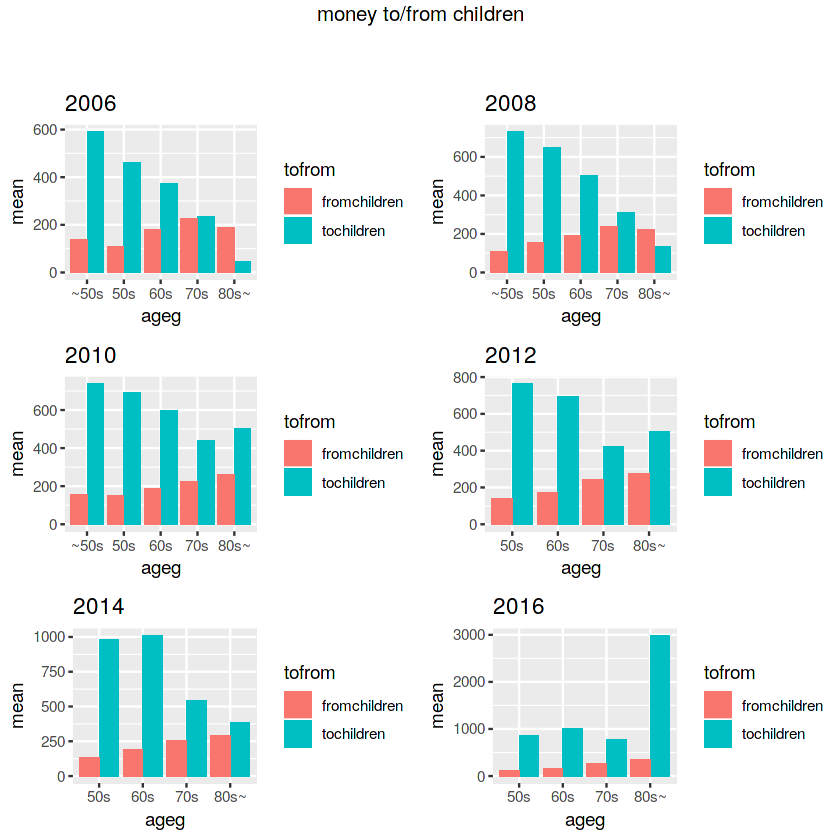

```r
grid.arrange(money_long2006 ,money_long2008 ,money_long2010 ,money_long2012 ,money_long2014 ,money_long2016 , ncol=2, top="money to/from children\n\n")
```

## 5. 소비

### 5.1 연도별 소비항목

- 월평균 금액(단위:만원)
- living_expenses: 생활비
- food_expenses: 식비
- eating_out_expenses: 외식비
- public_education_expenses: 공교육비
- private_education_expenses: 사교육비
- housing_expenses: 주거비
- medical_expenses: 지보건의료비
- savings: 저축액(일반저축, 적금, 보험, 개인연금 등 포함)

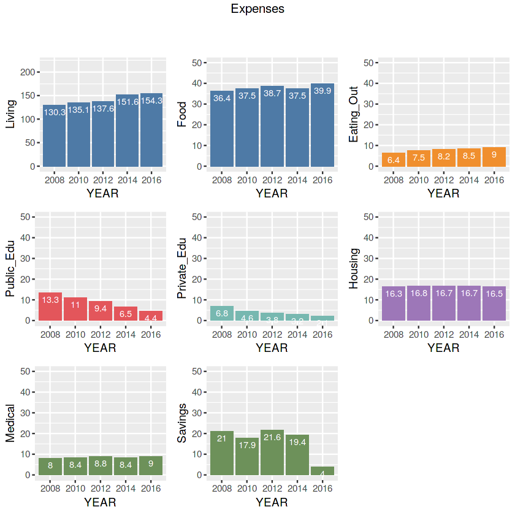

```r
klosa %>%
filter(year!=2006) %>%
select(year,living_expenses, food_expenses ,eating_out_expenses,public_education_expenses,private_education_expenses,housing_expenses,medical_expenses,savings) %>%
group_by(year) %>%
summarize(living_expenses = sprintf("%.1f", mean(living_expenses,na.rm=T)),
         food_expenses=sprintf("%.1f", mean(food_expenses,na.rm=T)),
         eating_out_expenses=sprintf("%.1f", mean(eating_out_expenses,na.rm=T)),
         public_education_expenses=sprintf("%.1f", mean(public_education_expenses,na.rm=T)),
         private_education_expenses=sprintf("%.1f", mean(private_education_expenses,na.rm=T)),
         housing_expenses=sprintf("%.1f", mean(housing_expenses,na.rm=T)),
         medical_expenses=sprintf("%.1f", mean(medical_expenses,na.rm=T)),
         savings=sprintf("%.1f", mean(savings,na.rm=T))) -> expenses
expenses$living_expenses=as.numeric(expenses$living_expenses)
expenses$food_expenses=as.numeric(expenses$food_expenses)
expenses$eating_out_expenses=as.numeric(expenses$eating_out_expenses)
expenses$public_education_expenses=as.numeric(expenses$public_education_expenses)
expenses$private_education_expenses=as.numeric(expenses$private_education_expenses)
expenses$housing_expenses=as.numeric(expenses$housing_expenses)
expenses$medical_expenses=as.numeric(expenses$medical_expenses)
expenses$savings=as.numeric(expenses$savings)


expenses  %>% ggplot(aes(factor(year),living_expenses))+geom_col(fill="#4e7aa6")+
                                    geom_text(aes(label=living_expenses), vjust=1.5, colour="white", size=3)+labs(x="YEAR",y="Living")+ylim(0,220)-> ex0
expenses  %>% ggplot(aes(factor(year),food_expenses))+geom_col(fill="#4e7aa6")+
                                    geom_text(aes(label=food_expenses), vjust=1.5, colour="white", size=3)+labs(x="YEAR",y="Food")+ylim(0,50)-> ex1
expenses  %>% ggplot(aes(factor(year),eating_out_expenses))+geom_col(fill="#f08f2e")+
                                    geom_text(aes(label=eating_out_expenses), vjust=1.5, colour="white", size=3)+labs(x="YEAR",y="Eating_Out")+ylim(0,50)-> ex2
expenses  %>% ggplot(aes(factor(year),public_education_expenses))+geom_col(fill="#e3565b")+
                                    geom_text(aes(label=public_education_expenses), vjust=1.5, colour="white", size=3)+labs(x="YEAR",y="Public_Edu")+ylim(0,50)-> ex3
expenses  %>% ggplot(aes(factor(year),private_education_expenses))+geom_col(fill="#77b8b0")+
                                    geom_text(aes(label=private_education_expenses), vjust=1.5, colour="white", size=3)+labs(x="YEAR",y="Private_Edu")+ylim(0,50)-> ex4
expenses  %>% ggplot(aes(factor(year),housing_expenses))+geom_col(fill="#9d77b8")+
                                    geom_text(aes(label=housing_expenses), vjust=1.5, colour="white", size=3)+labs(x="YEAR",y="Housing")+ylim(0,50)-> ex5
expenses  %>% ggplot(aes(factor(year),medical_expenses))+geom_col(fill="#6d915a")+
                                    geom_text(aes(label=medical_expenses), vjust=1.5, colour="white", size=3)+labs(x="YEAR",y="Medical")+ylim(0,50)-> ex6
expenses  %>% ggplot(aes(factor(year),savings))+geom_col(fill="#6d915a")+
                                    geom_text(aes(label=savings), vjust=1.5, colour="white", size=3)+labs(x="YEAR",y="Savings")+ylim(0,50)-> ex7
grid.arrange(ex0,ex1,ex2,ex3,ex4,ex5,ex6,ex7 ,   nrow=3, top="Expenses\n\n")
```

## 6. 건강상태

### 6.1 ADL(Activities of Daily Living) - 일상생활 수행 능력

- change_clothes: 옷갈아입기
- bath: 목욕/샤워하기
- meal: 차려놓은 음식 식사하기
- out_of_room: 이부자리에서 일어나 방 밖으로 나오기
- toilet: 화장실 이용하기
- urin: 대소변 조절하기

### 1) ADL 장애율

```r
klosa %>% select(year,ageg, adl) %>%
    mutate(adl=ifelse(adl > 0, 1, 0)) %>%
    count(year,ageg,adl) %>%
    group_by(year,ageg) %>%
    mutate(total=sum(n)) %>%
    filter(adl==1) %>%
    mutate(pct=round(n/total*100,1))-> adl_rate
```

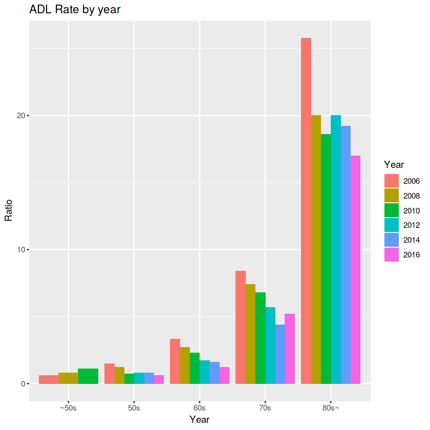

```r
adl_rate %>% ggplot(aes(ageg,pct,fill=factor(year)))+
    geom_col(position="dodge")+
    labs(y="Ratio",x="Year",title="ADL Rate by year") +
    theme_grey()+
    scale_fill_discrete(name = "Year")
```

### 2) 성별 ADL 장애율

```r
klosa %>% select(year,gender, adl) %>%
    mutate(adl=ifelse(adl > 0, 1, 0)) %>%
    count(year,gender,adl) %>%
    group_by(year,gender) %>%
    mutate(total=sum(n)) %>%
    filter(adl==1) %>%
    mutate(pct=round(n/total*100,1))-> adl_genrate
```

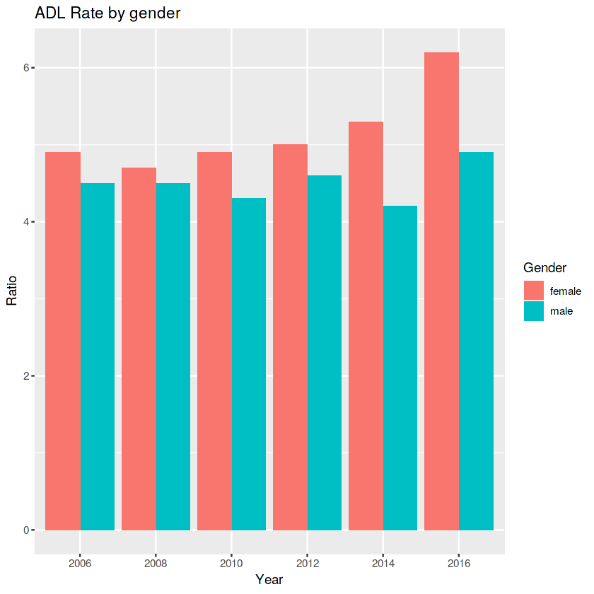

```r
adl_genrate %>% ggplot(aes(factor(year),pct,fill=factor(gender)))+
    geom_col(position="dodge")+
    labs(y="Ratio",x="Year",title="ADL Rate by gender") +
    theme_grey()+
    scale_fill_discrete(name = "Gender")
```